# Bitcoin Price Forecasting Using Time Series Models

March 9, 2026

```r
library(quantmod)
library(zoo)
library(xts)
library(tseries)
library(forecast)
library(FinTS)
library(rugarch)
library(vars)
library(MTS)
library(tidyverse)
library(reshape2)
library(bsts)
library(PerformanceAnalytics)
library(scales)
library(fredr)
```

# Problem Statement

## Objective

Bitcoin (BTC) is the world’s largest cryptocurrency by market capitalization and is known for extreme price volatility — daily swings of 5–15% are common. Accurately forecasting BTC’s daily price (or returns) would enable traders and portfolio managers to identify entry/exit opportunities and better manage risk.

This project asks: **Can the inclusion of macroeconomic indicators, market indices, and volatility dynamics improve Bitcoin forecasts compared to a univariate time-series baseline?**

## Research Questions

1. Does BTC exhibit ARCH/GARCH effects, indicating volatility clustering? If so, does a VAR-GARCH model forecast BTC better than BSTS or SARIMA, which do not explicitly model conditional volatility?
2. Do macroeconomic and market variables—SPY, QQQ, Fed Funds, the 10-Year Treasury yield, CPI, and unemployment—Granger-cause BTC returns? If so, do multivariate models such as VAR and BSTS improve forecast accuracy relative to a univariate SARIMA benchmark?
3. Does a BSTS model with regressors, trend, and seasonality outperform a VAR model in forecasting BTC?
4. Does a rolling VAR model with GARCH, which adds both time-varying volatility modeling and parameter re-estimation relative to the static VAR, lower forecast error?

## Scope

# Assumptions and Hypotheses

## Modeling Assumptions

1. **Log-returns for GARCH/VAR:** Raw prices are non-stationary (unit-root), so we work with log-returns `r_t = log(P_t / P_{t-1}) × 100` for volatility and multivariate models.
2. **Log-prices for SARIMA/BSTS:** Log-prices preserve the interpretation of the series in level terms while helping stabilize variance. In SARIMA, stationarity is achieved through explicit differencing specified in the model (the d parameter), while BSTS models nonstationary behavior through latent components such as trend and seasonal states rather than explicit differencing.
3. **Stationarity after differencing:** We assume one round of log-differencing is sufficient to induce stationarity in all series. This is verified empirically via ADF and KPSS tests.
4. **Data Frequency Alignment:** Lower-frequency series—such as CPI and UNRATE (monthly) and DGS10 and DFF (weekdays only)—are aligned to a daily frequency using forward-filling, with backward-filling applied when no prior value is available. This assumes that the most recent observed value remains in effect until a new release is available, which is a standard approach when integrating macroeconomic data with higher-frequency financial series.
5. **Constant model parameters over the training window:** VAR and GARCH parameters are assumed stable. Given the 10-year window includes crypto bull and bear cycles, this is a simplifying assumption.

## Hypotheses

- **H1 (ARCH effect):** BTC returns exhibit significant ARCH effects due to volatility clustering (e.g., news-driven spikes). Therefore, a VAR+GARCH model is expected to outperform a standard VAR model by explicitly modeling time-varying volatility.
- **H2 (Macro linkage):** At least one macroeconomic or market variable Granger-causes BTC returns, suggesting that BTC is influenced by broader financial conditions. Therefore, multivariate models that incorporate these variables, such as VAR and BSTS, are expected to outperform a univariate SARIMA model.
- **H3 (Static VAR vs Rolling VAR+GARCH):** A rolling VAR+GARCH forecast, which adds both time-varying volatility modeling and parameter re-estimation relative to the static VAR, will produce lower forecast error.
- **H4 (BSTS flexibility):** Because BSTS jointly models latent trend, seasonality, and regression effects, it is expected to provide competitive forecasts of BTC log-prices relative to the other approaches.

# Data

## Data Sources

```r
# Entire Dataset Start and End Date
start_date <- as.Date("2016-01-01")
end_date <- as.Date("2026-01-01")

# Test Set Start Date
test_start <- as.Date("2025-06-01")

# ── Set your FRED API key ──────────────────────────────────────────────────────
# Get a free key at: https://fred.stlouisfed.org/docs/api/api_key.html
# Then replace the string below, or set it via:
#   usethis::edit_r_environ()  and add  FRED_API_KEY=your_key_here
fredr_set_key("32232ec8ba8f84fd7d9e8c535a0f04c9")

# ── Helper: fredr tibble → xts ────────────────────────────────────────────────
fredr_to_xts <- function(series_id, col_name, start = start_date, end = end_date) {
  df <- fredr(series_id     = series_id,
              observation_start = start,
              observation_end = end,
              frequency     = NULL)   # keep native frequency
  x <- xts(df$value, order.by = as.Date(df$date))
  colnames(x) <- col_name
  x
}

# ── Crypto & Equity (quantmod / Yahoo — unchanged) ───────────────────────────
getSymbols("BTC-USD", src = "yahoo", from = start_date, to = end_date)
```

```
## [1] "BTC-USD"
```

```r
btc <- Ad(`BTC-USD`); colnames(btc) <- "BTC"

getSymbols("SPY", src = "yahoo", from = start_date, to = end_date)
```

```
## [1] "SPY"
```

```r
spy <- Ad(SPY); colnames(spy) <- "SPY"

getSymbols("QQQ", src = "yahoo", from = start_date, to = end_date)
```

```
## [1] "QQQ"
```

```r
qqq <- Ad(QQQ); colnames(qqq) <- "QQQ"

# ── Macro (fredr) ─────────────────────────────────────────────────────────────
fed    <- fredr_to_xts("DFF",      "FedFunds")   # Fed Funds Rate (daily)
dgs10  <- fredr_to_xts("DGS10",   "DGS10")       # 10-yr Treasury (daily weekdays)
cpi    <- fredr_to_xts("CPIAUCSL","CPI")          # CPI (monthly)
unrate <- fredr_to_xts("UNRATE",  "Unemployment") # Unemployment rate (monthly)
```

**Variable descriptions:**

| Variable | Source | Frequency | Description |
| --- | --- | --- | --- |
| BTC-USD | Yahoo | Daily | Bitcoin adjusted closing price |
| SPY | Yahoo | Daily | S&P 500 ETF (broad US equity) |
| QQQ | Yahoo | Daily | Nasdaq-100 ETF (tech equity) |
| DFF | FRED (fredr) | Daily | Effective Federal Funds Rate |
| DGS10 | FRED (fredr) | Daily (weekdays) | 10-Year Treasury Constant Maturity |
| CPIAUCSL | FRED (fredr) | Monthly | Consumer Price Index (all urban consumers) |
| UNRATE | FRED (fredr) | Monthly | US Civilian Unemployment Rate |

## Data Merging and Imputation

```r
# Merge all series
daily_data <- merge(btc, spy, qqq, fed, dgs10, cpi, unrate)

# Restrict to start date
daily_data <- daily_data[index(daily_data) >= start_date]

# Expand to full calendar (including weekends / holidays)
full_dates <- seq(from = min(index(daily_data)),
                  to   = max(index(daily_data)),
                  by   = "day")

daily_data <- merge(daily_data, xts(order.by = full_dates), fill = NA)

# Forward fill (carry last known value forward)
daily_data <- na.locf(daily_data, na.rm = FALSE)

# Backward fill for any leading NAs at the start
daily_data <- na.locf(daily_data, fromLast = TRUE)

cat("Dataset dimensions:", dim(daily_data), "\n")
```

```
## Dataset dimensions: 3654 7
```

```r
cat("Date range:", as.character(start(daily_data)), "to", as.character(end(daily_data)), "\n")
```

```
## Date range: 2016-01-01 to 2026-01-01
```

**Imputation rationale:** Markets for BTC trade 24/7 but SPY/QQQ do not trade on weekends and US holidays. Macro series (CPI, UNRATE) are released monthly. Forward-fill is used because the last observed value is the best available estimate until a new release or trading day. No linear interpolation is used to avoid look-ahead bias.

# Data Properties and Exploratory Data Analysis (EDA)

```r
# EDA function: summary stats + level plot + returns plot + QQ + ACF/PACF + stationarity tests
eda <- function(x, name, arch_lags = 12) {
  cat("===== EDA:", name, "=====\n")

  x_num <- as.numeric(x)
  x_num <- x_num[is.finite(x_num)]

  print(summary(x_num))
  cat("Mean:     ", round(mean(x_num, na.rm = TRUE), 4), "\n")
  cat("SD:       ", round(sd(x_num, na.rm = TRUE), 4), "\n")
  cat("Skewness: ", round(PerformanceAnalytics::skewness(x_num, na.rm = TRUE), 4),
      " (>0 = right tail, <0 = left tail)\n")
  cat("Kurtosis: ", round(PerformanceAnalytics::kurtosis(x_num, na.rm = TRUE), 4),
      " (>3 = heavy tails relative to normal)\n")

  old_par <- par(no.readonly = TRUE)
  on.exit(par(old_par))
  par(mfrow = c(2, 2))

  # Level plot
  plot.ts(x_num,
          main = paste(name, "— Time Series"),
          col = "steelblue", lwd = 1.2,
          xlab = "Time", ylab = name)

  # QQ plot
  qqnorm(x_num, main = paste("QQ Plot:", name))
  qqline(x_num, col = "red", lwd = 2)

  # ACF/PACF
  Acf(x_num, main = paste("ACF —", name), lag.max = 40)
  Pacf(x_num, main = paste("PACF —", name), lag.max = 40)

  par(mfrow = c(1, 1))

  cat("\nADF Test (H0: unit root):\n")
  print(adf.test(x_num))

  cat("\nKPSS Test (H0: stationary):\n")
  print(kpss.test(x_num))

  cat("\nARCH LM Test (H0: no ARCH effects):\n")
  print(FinTS::ArchTest(x_num, lags = arch_lags))
  cat("\n")
}
```

## Target Variable: BTC Log-Returns and Log-Price

```r
# Compute log-returns (%)
btc_ret <- diff(log(daily_data$BTC)) * 100
btc_ret <- na.omit(btc_ret)
```

```r
# Compute log-price
btc_log <- log(daily_data$BTC)
btc_log <- na.omit(btc_log)
```

```r
eda(btc_ret, "BTC Log-Returns (%)")
```

```
## ===== EDA: BTC Log-Returns (%) =====
##     Min.  1st Qu.   Median     Mean  3rd Qu.     Max.
## -46.4730  -1.2475   0.1244   0.1456   1.5892  22.5119
## Mean:      0.1456
## SD:        3.5334
## Skewness:  -0.6675  (>0 = right tail, <0 = left tail)
## Kurtosis:  12.2485  (>3 = heavy tails relative to normal)
```

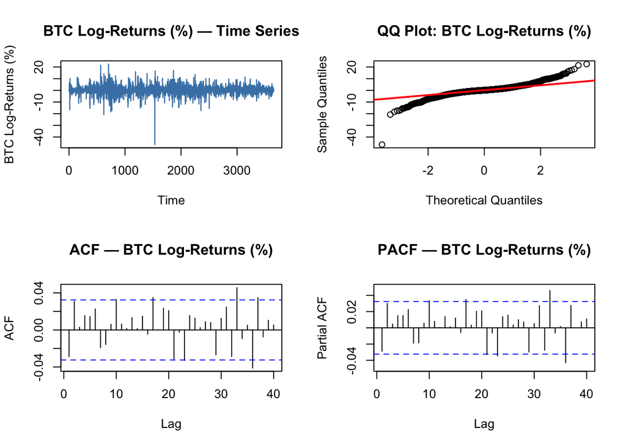

```
##
## ADF Test (H0: unit root):
```

```
##
##  Augmented Dickey-Fuller Test
##
## data:  x_num
## Dickey-Fuller = -14.374, Lag order = 15, p-value = 0.01
## alternative hypothesis: stationary
##
##
## KPSS Test (H0: stationary):
```

```
##
##  KPSS Test for Level Stationarity
##
## data:  x_num
## KPSS Level = 0.2075, Truncation lag parameter = 9, p-value = 0.1
##
##
## ARCH LM Test (H0: no ARCH effects):
##
##  ARCH LM-test; Null hypothesis: no ARCH effects
##
## data:  x_num
## Chi-squared = 115.36, df = 12, p-value < 2.2e-16
```

**Interpretation:** BTC log-returns have a small positive mean return (0.146%) but substantial volatility (SD = 3.53%), with the distribution showing negative skewness (−0.67) and very high kurtosis (12.25), indicating that large negative shocks and extreme movements occur more often than under normality. This is also evident in the QQ plot, where both tails deviate notably from the reference line, confirming a heavy-tailed, non-normal distribution. The time-series plot suggests volatility clustering, with calm periods followed by turbulent periods, which is consistent with conditional heteroskedasticity and supports the use of GARCH-type models. At the same time, the ACF and PACF of returns show only weak serial correlation at most lags, implying limited linear dependence in the mean process. Furthermore, the stationarity tests agree that BTC log-returns are stationary: the ADF test rejects the unit root null, while the KPSS test fails to reject stationarity, making the series suitable for return-based models such as ARMA, VAR, and GARCH. Finally, the ARCH LM test strongly rejects the null hypothesis of no ARCH effects indicating significant volatility clustering and supporting the use of GARCH-type models to capture time-varying variance in BTC returns.

```r
eda(btc_log, "BTC Log-Price")
```

```
## ===== EDA: BTC Log-Price =====
##    Min. 1st Qu.  Median    Mean 3rd Qu.    Max.
##   5.898   8.767   9.749   9.497  10.746  11.734
## Mean:      9.4972
## SD:        1.5541
## Skewness:  -0.6763  (>0 = right tail, <0 = left tail)
## Kurtosis:  -0.3874  (>3 = heavy tails relative to normal)
```

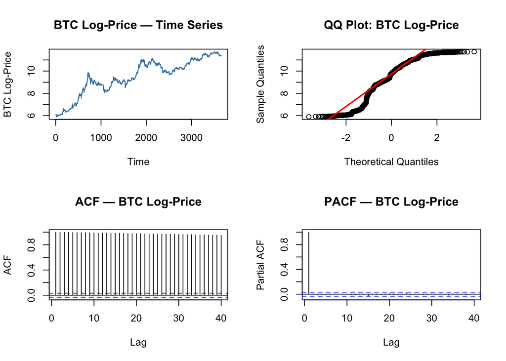

```
##
## ADF Test (H0: unit root):
##
##  Augmented Dickey-Fuller Test
##
## data:  x_num
## Dickey-Fuller = -2.2204, Lag order = 15, p-value = 0.485
## alternative hypothesis: stationary
##
##
## KPSS Test (H0: stationary):
```

```
##
##  KPSS Test for Level Stationarity
##
## data:  x_num
## KPSS Level = 30.253, Truncation lag parameter = 9, p-value = 0.01
##
##
## ARCH LM Test (H0: no ARCH effects):
##
##  ARCH LM-test; Null hypothesis: no ARCH effects
##
## data:  x_num
## Chi-squared = 3639.9, df = 12, p-value < 2.2e-16
```

**Interpretation:** BTC log-price shows a strong upward trend over time, reflecting the long-term growth of the asset, with values ranging from about 5.90 to 11.73 and an average of 9.50. The distribution is slightly negatively skewed (−0.68), indicating somewhat more mass in the upper range of prices relative to the lower range, while the kurtosis (−0.39) suggests lighter tails compared with a normal distribution, which is typical for trending level series rather than returns. The QQ plot confirms deviations from normality, particularly due to the trend structure in the data. The ACF displays very high persistence across many lags, while the PACF shows a large spike at the first lag followed by near-zero values, both of which are characteristic of a nonstationary time series with a stochastic trend. The formal stationarity tests support this: the ADF test fails to reject the unit root null (p = 0.485), and the KPSS test rejects the null of stationarity (p = 0.01). Together, these results indicate that BTC log-price is nonstationary and likely contains a unit root, meaning differencing or state-space trend modeling (e.g., SARIMA differencing or BSTS trend components) is required before forecasting.Finally, the ARCH LM test strongly rejects the null hypothesis of no ARCH effects indicating significant volatility clustering and supporting the use of GARCH-type models to capture time-varying variance in BTC price.

## Correlation Structure

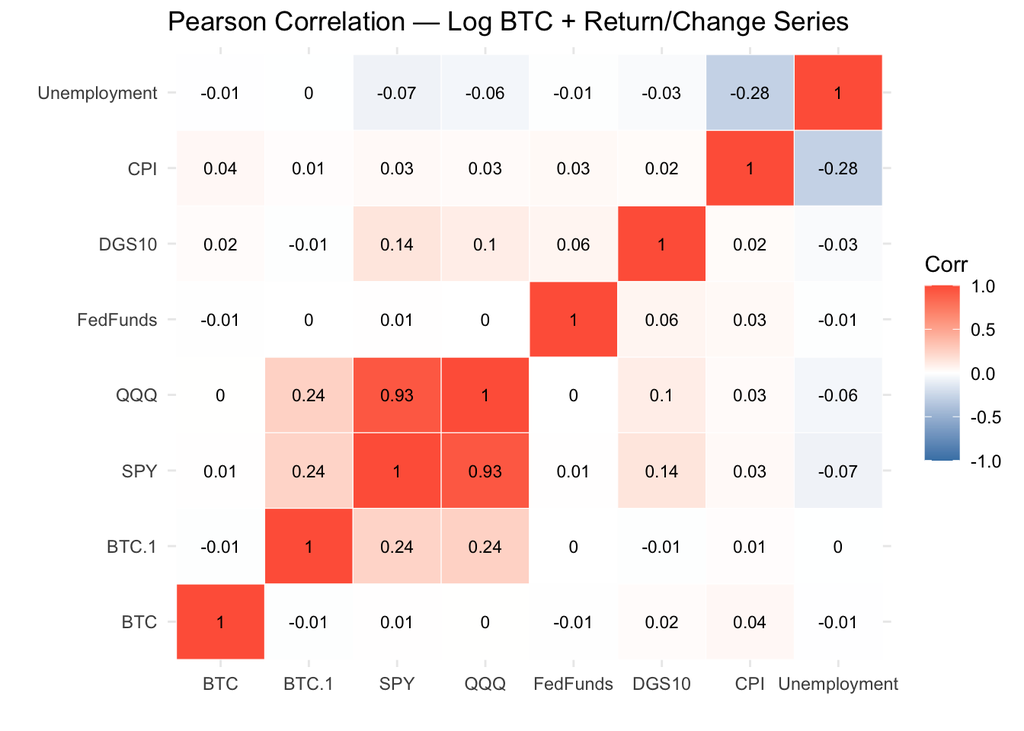

```r
# Build dataframe for correlation analysis
pBTC_c <- log(daily_data$BTC)
rBTC_c <- diff(log(daily_data$BTC)) * 100
rSPY_c <- diff(log(daily_data$SPY)) * 100
rQQQ_c <- diff(log(daily_data$QQQ)) * 100
dFF_c  <- diff(daily_data$FedFunds)
dGS10_c <- diff(daily_data$DGS10)
dCPI_c  <- diff(log(daily_data$CPI)) * 100
dUNR_c  <- diff(daily_data$Unemployment)

corr_df <- na.omit(data.frame(
  pBTC = pBTC_c,
  rBTC = rBTC_c,
  rSPY = rSPY_c,
  rQQQ = rQQQ_c,
  dFF = dFF_c,
  dGS10 = dGS10_c,
  dCPI = dCPI_c,
  dUNR = dUNR_c
))

cor_mat <- cor(corr_df)

# Melt for ggplot heatmap
cor_long <- reshape2::melt(cor_mat)

ggplot(cor_long, aes(Var1, Var2, fill = value)) +
  geom_tile(color = "white") +
  geom_text(aes(label = round(value, 2)), size = 3) +
  scale_fill_gradient2(low = "steelblue", mid = "white", high = "tomato",
                       midpoint = 0, limits = c(-1, 1)) +
  theme_minimal() +
  labs(title = "Pearson Correlation — Log BTC + Return/Change Series",
       x = "", y = "", fill = "Corr")
```

**Key observations:** The correlation matrix shows that BTC returns have moderate positive correlations with equity market returns, particularly SPY and QQQ (≈0.24), suggesting that BTC sometimes moves with broader risk assets. As expected, SPY and QQQ are extremely highly correlated (≈0.93) because both represent large-cap U.S. equities with heavy overlap in holdings. In contrast, correlations between BTC returns and macroeconomic variables such as Fed Funds, the 10-year Treasury yield (DGS10), CPI changes, and unemployment changes are very close to zero, indicating little contemporaneous linear relationship. The BTC log-price itself also shows near-zero correlations with these differenced macro variables, which is consistent with the fact that the macro series represent changes while BTC log-price is a level series. Overall, the heatmap suggests that BTC is more connected to equity market movements than to short-run macroeconomic fluctuations, though the relationships remain relatively weak outside of the equity indices.

# Data Processing

## Anomaly Detection

```r
# Flag extreme BTC return observations (beyond 3 SD)
mu  <- mean(btc_ret, na.rm = TRUE)
sig <- sd(btc_ret, na.rm = TRUE)

outliers <- btc_ret[abs(btc_ret - mu) > 3 * sig]

cat("Observations beyond ±3σ:", length(outliers), "\n")
```

```
## Observations beyond ±3σ: 65
```

```r
cat("Dates of extreme moves:\n")
```

```
## Dates of extreme moves:
```

```r
print(head(outliers, 20))
```

```
##                  BTC
## 2016-01-15 -16.64338
## 2016-05-28  11.28766
## 2016-06-22 -11.18328
## 2017-01-05 -13.05753
## 2017-01-06 -11.62092
## 2017-01-11 -15.44766
## 2017-03-18 -12.20501
## 2017-06-12 -10.63636
## 2017-07-15 -11.09213
## 2017-07-17  14.38616
## 2017-07-20  21.45958
## 2017-08-05  11.62575
## 2017-09-14 -20.75298
## 2017-09-15  14.23295
## 2017-09-18  12.62960
## 2017-10-12  12.09311
## 2017-12-06  18.17242
## 2017-12-07  22.51190
## 2017-12-22 -13.32232
## 2017-12-26  13.78513
```

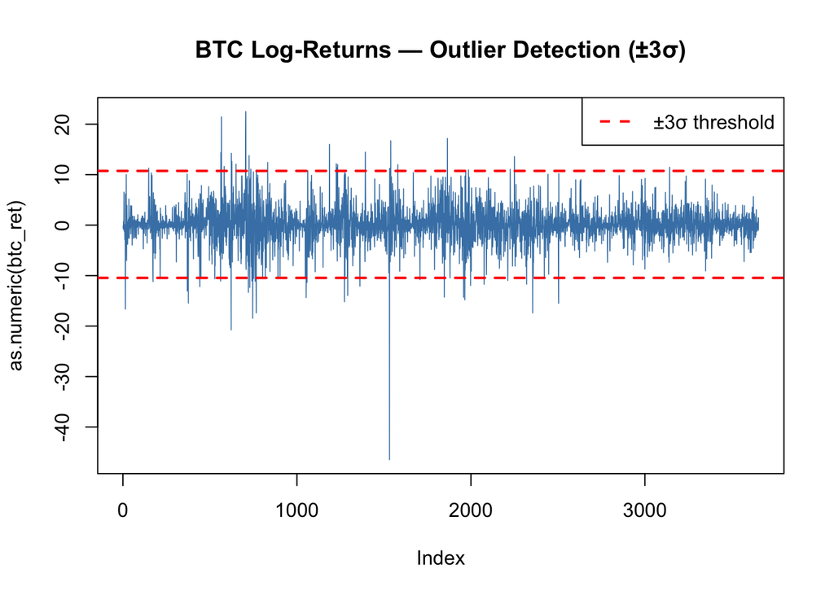

```r
# Plot with outlier threshold
plot(as.numeric(btc_ret),
     type = "l",
     main = "BTC Log-Returns — Outlier Detection (±3σ)",
     col = "steelblue",
     lwd = 0.8)

abline(h = c(mu + 3*sig, mu - 3*sig),
       col = "red",
       lty = 2,
       lwd = 2)

legend("topright",
       legend = "±3σ threshold",
       col = "red",
       lty = 2,
       lwd = 2)
```

**Decision:** The analysis identifies 65 observations beyond the ±3σ threshold, indicating the presence of extreme outliers in BTC returns. However, these observations are retained because, in financial time series, large price movements typically reflect genuine market events—such as regulatory announcements, liquidity shocks, exchange failures, or sudden shifts in investor sentiment—rather than data errors. Removing them would distort the true distribution of returns and understate the volatility and risk inherent in the asset. Their presence is consistent with the heavy-tailed behavior observed in the EDA, and the Student-t distribution used in the GARCH model is specifically designed to accommodate such extreme observations.

## Missing Value Summary

```r
na_counts <- colSums(is.na(daily_data))
cat("Missing values per series AFTER imputation:\n")
```

```
## Missing values per series AFTER imputation:
```

```r
print(na_counts)
```

```
##          BTC          SPY          QQQ     FedFunds        DGS10          CPI
##            0            0            0            0            0            0
## Unemployment
##            0
```

# Feature Engineering

## Stationary Transformations

```r
# All series transformed to stationarity before modeling
pBTC  <- log(daily_data$BTC)
rBTC  <- diff(log(daily_data$BTC))   * 100   # log-return (%)
rSPY  <- diff(log(daily_data$SPY))   * 100   # log-return (%)
rQQQ  <- diff(log(daily_data$QQQ))   * 100   # log-return (%)
dFF   <- diff(daily_data$FedFunds)           # 1st-diff of rate level
dGS10 <- diff(daily_data$DGS10)              # 1st-diff of rate level
dCPI  <- diff(log(daily_data$CPI))   * 100   # log-return (%)
dUNR  <- diff(daily_data$Unemployment)       # 1st-diff of rate level

var_df <- na.omit(merge(pBTC, rBTC, rSPY, rQQQ, dFF, dGS10, dCPI, dUNR))
colnames(var_df) <- c("pBTC", "rBTC","rSPY","rQQQ","dFF","dGS10","dCPI","dUNR")

cat("Feature matrix dimensions:", dim(var_df), "\n")
```

```
## Feature matrix dimensions: 3653 8
```

```r
head(var_df)
```

```
##                pBTC       rBTC       rSPY       rQQQ  dFF dGS10 dCPI dUNR
## 2016-01-02 6.071749 -0.2065121  0.0000000  0.0000000 0.00  0.00    0    0
## 2016-01-03 6.063811 -0.7937979  0.0000000  0.0000000 0.00  0.00    0    0
## 2016-01-04 6.070948  0.7137118  0.0000000  0.0000000 0.16  0.00    0    0
## 2016-01-05 6.068333 -0.2614904  0.1689851 -0.1736680 0.00  0.01    0    0
## 2016-01-06 6.061702 -0.6631302 -1.2694236 -0.9652362 0.00 -0.07    0    0
## 2016-01-07 6.126974  6.5272321 -2.4284198 -3.1814373 0.00 -0.02    0    0
```

**Feature engineering rationale:**

| Raw Variable | Transformation | Reason |
| --- | --- | --- |
| BTC | Log | Preserves the level-series interpretation for price modeling while helping stabilize variance |
| BTC, SPY, QQQ prices; CPIAUCSL | Log-difference × 100 | Converts prices and the CPI index into percentage changes, helping remove trend/nonstationarity and making the transformed series easier to compare across variables |
| DFF, DGS10, UNRATE | First difference | Converts levels into changes, which are more likely to be stationary than the original series |

## EDA of Regressors

```r
# EDA for SPY
eda(rSPY,  "SPY Log-Returns (%)")
```

```
## ===== EDA: SPY Log-Returns (%) =====
##      Min.   1st Qu.    Median      Mean   3rd Qu.      Max.
## -11.58867  -0.12713   0.00000   0.03797   0.31716   9.98629
## Mean:      0.038
## SD:        0.9432
## Skewness:  -0.6732  (>0 = right tail, <0 = left tail)
## Kurtosis:  23.2524  (>3 = heavy tails relative to normal)
```

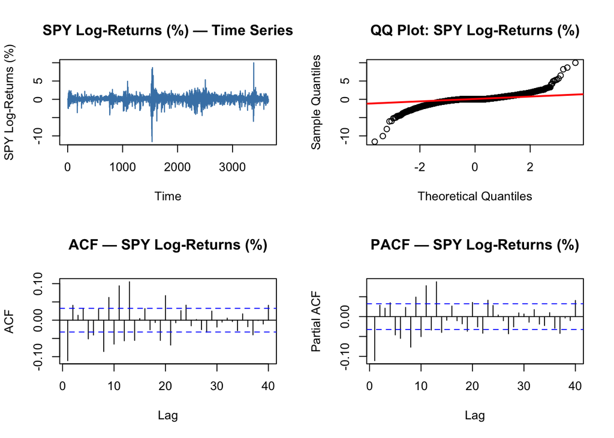

```
##
## ADF Test (H0: unit root):
```

```
##
##  Augmented Dickey-Fuller Test
##
## data:  x_num
## Dickey-Fuller = -14.74, Lag order = 15, p-value = 0.01
## alternative hypothesis: stationary
##
##
## KPSS Test (H0: stationary):
```

```
##
##  KPSS Test for Level Stationarity
##
## data:  x_num
## KPSS Level = 0.028483, Truncation lag parameter = 9, p-value = 0.1
##
##
## ARCH LM Test (H0: no ARCH effects):
##
##  ARCH LM-test; Null hypothesis: no ARCH effects
##
## data:  x_num
## Chi-squared = 852.28, df = 12, p-value < 2.2e-16
```

```
## ===== EDA: QQQ Log-Returns (%) =====
##      Min.   1st Qu.    Median      Mean   3rd Qu.      Max.
## -12.75923  -0.14648   0.00000   0.04919   0.41953  11.33561
## Mean:      0.0492
## SD:        1.1696
## Skewness:  -0.429  (>0 = right tail, <0 = left tail)
## Kurtosis:  12.7677  (>3 = heavy tails relative to normal)
```

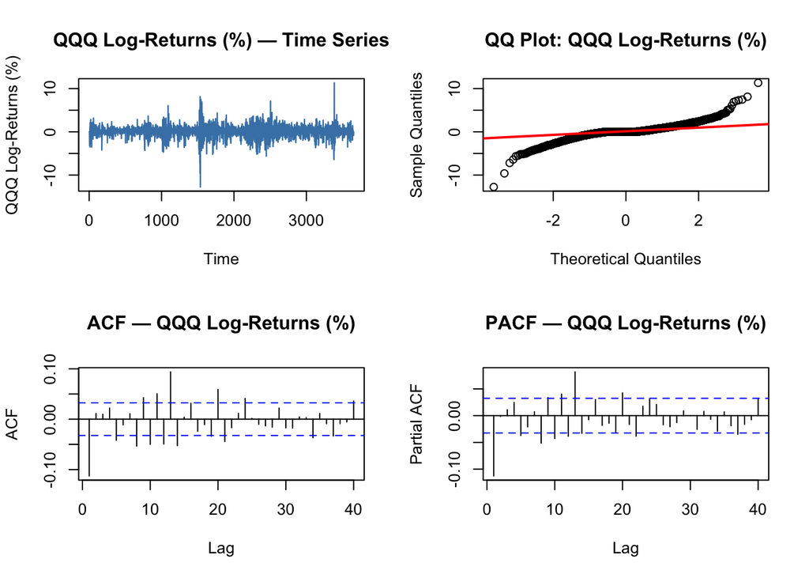

```
##
## ADF Test (H0: unit root):
```

```
##
##  Augmented Dickey-Fuller Test
##
## data:  x_num
## Dickey-Fuller = -14.96, Lag order = 15, p-value = 0.01
## alternative hypothesis: stationary
##
##
## KPSS Test (H0: stationary):
```

```
##
##  KPSS Test for Level Stationarity
##
## data:  x_num
## KPSS Level = 0.035879, Truncation lag parameter = 9, p-value = 0.1
##
##
## ARCH LM Test (H0: no ARCH effects):
##
##  ARCH LM-test; Null hypothesis: no ARCH effects
##
## data:  x_num
## Chi-squared = 616.57, df = 12, p-value < 2.2e-16
```

```r
# EDA for QQQ
eda(rQQQ,  "QQQ Log-Returns (%)")
```

```r
# EDA for FF
eda(dFF,   "Fed Funds Change")
```

```
## ===== EDA: Fed Funds Change =====
##       Min.    1st Qu.     Median       Mean    3rd Qu.       Max.
## -0.8500000  0.0000000  0.0000000  0.0009417  0.0000000  0.7500000
## Mean:      9e-04
## SD:        0.04
## Skewness:  4.6896  (>0 = right tail, <0 = left tail)
## Kurtosis:  224.8928  (>3 = heavy tails relative to normal)
```

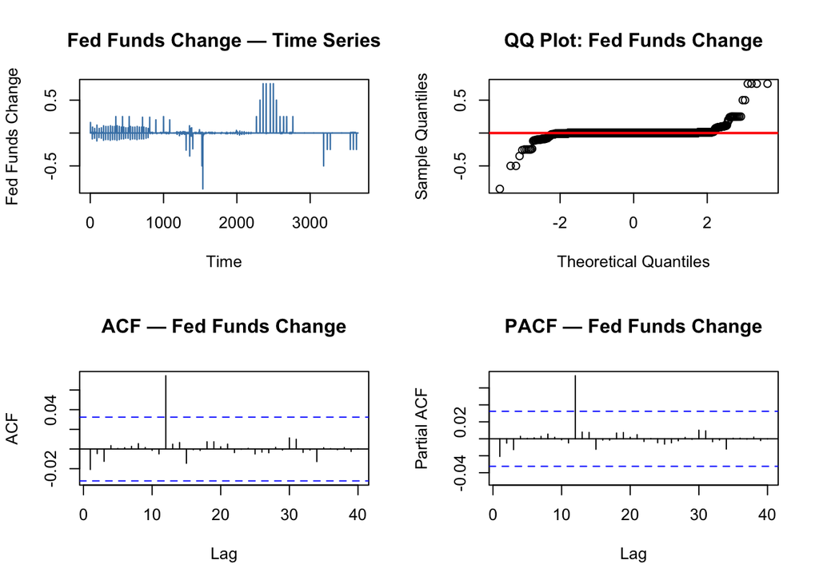

```
##
## ADF Test (H0: unit root):
```

```
##
##  Augmented Dickey-Fuller Test
##
## data:  x_num
## Dickey-Fuller = -14.235, Lag order = 15, p-value = 0.01
## alternative hypothesis: stationary
##
##
## KPSS Test (H0: stationary):
##
##  KPSS Test for Level Stationarity
##
## data:  x_num
## KPSS Level = 0.36406, Truncation lag parameter = 9, p-value = 0.09265
##
##
## ARCH LM Test (H0: no ARCH effects):
##
##  ARCH LM-test; Null hypothesis: no ARCH effects
##
## data:  x_num
## Chi-squared = 24.344, df = 12, p-value = 0.01826
```

```r
# EDA for GS10
eda(dGS10, "10-Year Treasury Change")
```

```
## ===== EDA: 10-Year Treasury Change =====
##       Min.    1st Qu.     Median       Mean    3rd Qu.       Max.
## -0.3000000 -0.0200000  0.0000000  0.0005311  0.0200000  0.2900000
## Mean:      5e-04
## SD:        0.0442
## Skewness:  -0.0648  (>0 = right tail, <0 = left tail)
## Kurtosis:  4.4176  (>3 = heavy tails relative to normal)
```

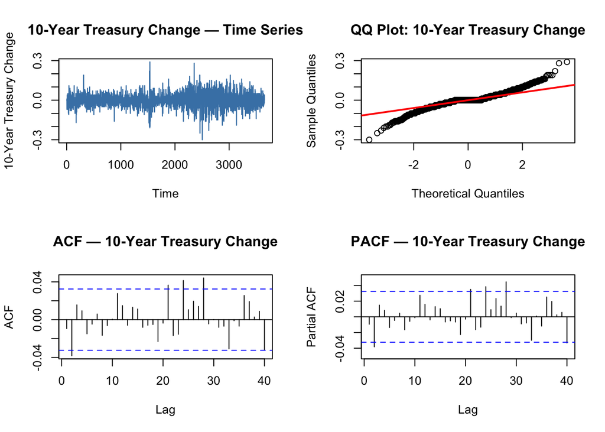

```
##
## ADF Test (H0: unit root):
```

```
##
##  Augmented Dickey-Fuller Test
##
## data:  x_num
## Dickey-Fuller = -14.702, Lag order = 15, p-value = 0.01
## alternative hypothesis: stationary
##
##
## KPSS Test (H0: stationary):
```

```
##
##  KPSS Test for Level Stationarity
##
## data:  x_num
## KPSS Level = 0.16632, Truncation lag parameter = 9, p-value = 0.1
##
##
## ARCH LM Test (H0: no ARCH effects):
##
##  ARCH LM-test; Null hypothesis: no ARCH effects
##
## data:  x_num
## Chi-squared = 353.88, df = 12, p-value < 2.2e-16
```

```r
# EDA for CPI
eda(dCPI,  "Inflation (Log-Diff %)")
```

```
## ===== EDA: Inflation (Log-Diff %) =====
##      Min.   1st Qu.    Median      Mean   3rd Qu.      Max.
## -0.795168  0.000000  0.000000  0.008702  0.000000  1.248278
## Mean:      0.0087
## SD:        0.0677
## Skewness:  8.4458  (>0 = right tail, <0 = left tail)
## Kurtosis:  112.4492  (>3 = heavy tails relative to normal)
```

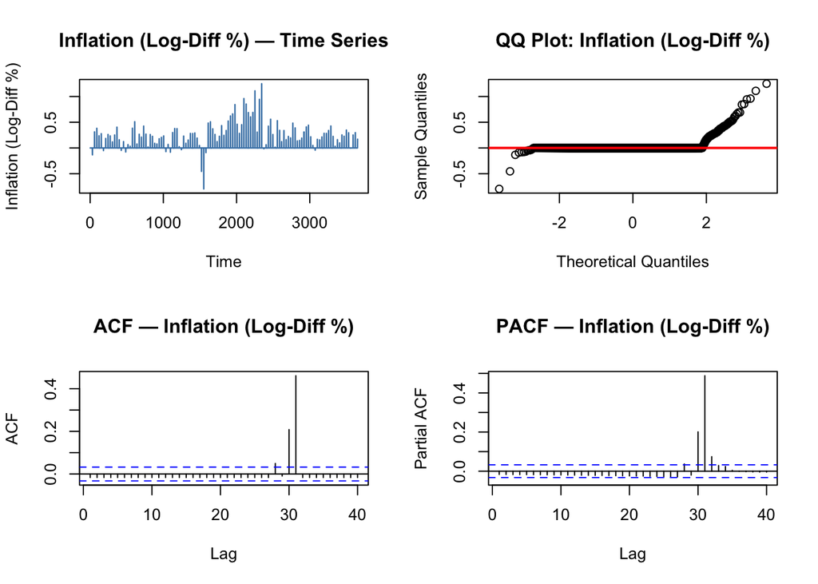

```
##
## ADF Test (H0: unit root):
```

```
##
##  Augmented Dickey-Fuller Test
##
## data:  x_num
## Dickey-Fuller = -17.783, Lag order = 15, p-value = 0.01
## alternative hypothesis: stationary
##
##
## KPSS Test (H0: stationary):
##
##  KPSS Test for Level Stationarity
##
## data:  x_num
## KPSS Level = 0.57077, Truncation lag parameter = 9, p-value = 0.02573
##
##
## ARCH LM Test (H0: no ARCH effects):
##
##  ARCH LM-test; Null hypothesis: no ARCH effects
##
## data:  x_num
## Chi-squared = 3.6636, df = 12, p-value = 0.9888
```

```r
# EDA for UNR
eda(dUNR,  "Unemployment Change")
```

```
## ===== EDA: Unemployment Change =====
##       Min.    1st Qu.     Median       Mean    3rd Qu.       Max.
## -2.2000000  0.0000000  0.0000000 -0.0001369  0.0000000 10.4000000
## Mean:      -1e-04
## SD:        0.184
## Skewness:  48.471  (>0 = right tail, <0 = left tail)
## Kurtosis:  2800.574  (>3 = heavy tails relative to normal)
```

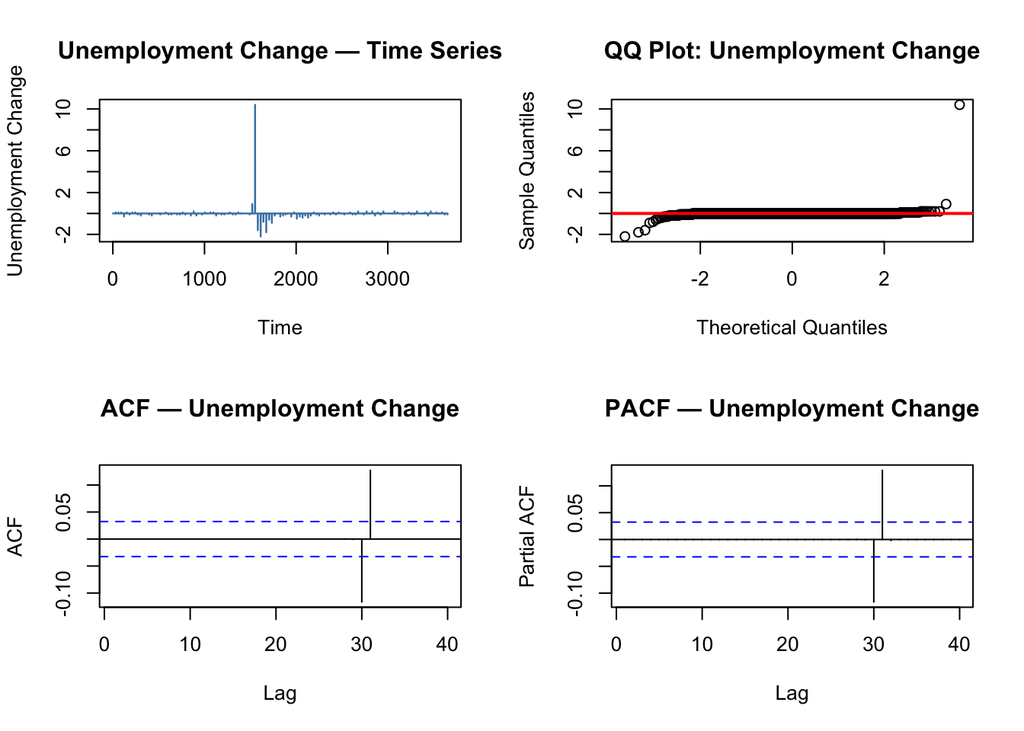

```
##
## ADF Test (H0: unit root):
```

```
##
##  Augmented Dickey-Fuller Test
##
## data:  x_num
## Dickey-Fuller = -15.039, Lag order = 15, p-value = 0.01
## alternative hypothesis: stationary
##
##
## KPSS Test (H0: stationary):
```

```
##
##  KPSS Test for Level Stationarity
##
## data:  x_num
## KPSS Level = 0.023502, Truncation lag parameter = 9, p-value = 0.1
##
##
## ARCH LM Test (H0: no ARCH effects):
##
##  ARCH LM-test; Null hypothesis: no ARCH effects
##
## data:  x_num
## Chi-squared = 0.0056213, df = 12, p-value = 1
```

**Interpretation:** The equity return series (rSPY and rQQQ) strongly reject the unit root null in the ADF test and fail to reject stationarity in the KPSS test, confirming that the log-return transformation successfully removes nonstationarity. Similar results hold for the macroeconomic variables after differencing or log-differencing: ADF tests reject the presence of a unit root while KPSS tests generally support stationarity, suggesting the transformations effectively remove persistent trends.

## Train / Test Split

```r
train_xts <- var_df[index(var_df) < test_start]
train_xts <- train_xts[, colnames(train_xts) != "pBTC"]

test_xts  <- var_df[index(var_df) >= test_start]
test_xts  <- test_xts[, colnames(test_xts) != "pBTC"]

cat("Train range:", as.character(start(index(train_xts))),
    "to", as.character(end(index(train_xts))), "\n")
```

```
## Train range: 1 1 to 3438 1
```

```r
cat("Train size:", nrow(train_xts), "observations\n")
```

```
## Train size: 3438 observations
```

```r
cat("Test  range:", as.character(start(index(test_xts))),
    "to", as.character(end(index(test_xts))), "\n")
```

```
## Test  range: 1 1 to 215 1
```

```r
cat("Test  size:", nrow(test_xts), "observations\n")
```

```
## Test  size: 215 observations
```

```r
train_Y <- as.matrix(train_xts)
test_Y  <- as.matrix(test_xts)
```

**Note:** The test set (June 2025 onward) is a true hold-out; no model is tuned on test data. The rolling 1-step-ahead evaluation in the VAR+GARCH section re-estimates the model at each step using only data available up to that point — eliminating look-ahead bias.

# Proposed Models

This section presents four models in order of complexity. Each is justified by both theoretical motivation and empirical diagnostics.

## Model 1: ARMA — Baseline Mean Model

The ARMA baseline tests whether BTC returns contain any linear autocorrelation structure in their **mean**. It serves as the mean equation for the GARCH model.

```r
arma_fit <- auto.arima(as.numeric(btc_ret),
                       d = 0,
                       stationary = TRUE,
                       seasonal   = FALSE,
                       max.p = 3, max.q = 3)

cat("Selected ARMA order:", arma_fit$arma[1], arma_fit$arma[2], "\n")
```

```
## Selected ARMA order: 0 2
```

```r
summary(arma_fit)
```

```
## Series: as.numeric(btc_ret)
## ARIMA(0,0,2) with non-zero mean
##
## Coefficients:
##           ma1     ma2    mean
##       -0.0282  0.0302  0.1456
## s.e.   0.0165  0.0163  0.0585
##
## sigma^2 = 12.47:  log likelihood = -9790.75
## AIC=19589.5   AICc=19589.51   BIC=19614.31
##
## Training set error measures:
##                         ME     RMSE      MAE  MPE MAPE      MASE         ACF1
## Training set -7.223406e-06 3.529851 2.302417 -Inf  Inf 0.6636069 7.717709e-05
```

**Key observations:** An ARMA(0,2) model (i.e., ARIMA(0,0,2) with a non-zero mean) was selected for the BTC log-returns, meaning returns are modeled as a constant mean plus a moving-average component driven by shocks from the previous two days. The estimated mean return is 0.1456% (s.e. 0.0585), while the MA coefficients are small (ma1 = −0.0282, s.e. 0.0165; ma2 = 0.0302, s.e. 0.0163), suggesting only weak short-run dependence in the return series. Model fit statistics are AIC = 19589.5 (AICc = 19589.51) and BIC = 19614.31, with estimated innovation variance σ² = 12.47 (log-likelihood −9790.75). On the training set, forecast errors are RMSE = 3.53 and MAE = 2.30, and the residual autocorrelation at lag 1 is essentially zero (ACF1 ≈ 0.00008), indicating the model leaves little linear autocorrelation in the mean process.

## Model 2: GARCH — Volatility Modeling

### ARCH Test (Pre-condition)

```r
# ARCH test: H0 = no ARCH effects
cat("ARCH Test on raw BTC returns:\n")
```

```
## ARCH Test on raw BTC returns:
```

```r
ArchTest(as.numeric(btc_ret), lags = 12)
```

```
##
##  ARCH LM-test; Null hypothesis: no ARCH effects
##
## data:  as.numeric(btc_ret)
## Chi-squared = 115.36, df = 12, p-value < 2.2e-16
```

**Interpretation:** A significant ARCH test (p < 0.05) confirms volatility clustering — large shocks tend to be followed by large shocks. This validates fitting a GARCH model.

### ARCH(1) — Benchmark Variance Model

```r
spec_arch <- ugarchspec(
  variance.model     = list(model = "sGARCH", garchOrder = c(1, 0)),
  mean.model         = list(armaOrder = c(0, 2), include.mean = TRUE),
  distribution.model = "norm"
)

fit_arch <- ugarchfit(spec = spec_arch, data = btc_ret)
show(fit_arch)
```

```
##
## *---------------------------------*
## *          GARCH Model Fit        *
## *---------------------------------*
##
## Conditional Variance Dynamics
## -----------------------------------
## GARCH Model  : sGARCH(1,0)
## Mean Model   : ARFIMA(0,0,2)
## Distribution : norm
##
## Optimal Parameters
## ------------------------------------
##         Estimate  Std. Error  t value Pr(>|t|)
## mu     -9.230924    0.004385  -2105.2        0
## ma1     1.806615    0.000014 125330.9        0
## ma2     0.818934    0.000026  31123.1        0
## omega   0.043498    0.000031   1400.2        0
## alpha1  0.391255    0.000267   1466.6        0
##
## Robust Standard Errors:
##         Estimate  Std. Error   t value Pr(>|t|)
## mu     -9.230924   117.00500 -0.078893 0.937117
## ma1     1.806615     0.19469  9.279534 0.000000
## ma2     0.818934     0.20651  3.965646 0.000073
## omega   0.043498     0.58032  0.074955 0.940251
## alpha1  0.391255     5.00711  0.078140 0.937717
##
## LogLikelihood : -30561.27
##
## Information Criteria
## ------------------------------------
##
## Akaike       16.735
## Bayes        16.743
## Shibata      16.735
## Hannan-Quinn 16.738
##
## Weighted Ljung-Box Test on Standardized Residuals
## ------------------------------------
```

[output cut: 40 more lines]

```
## Negative Sign Bias  1.7864 0.07411   *
## Positive Sign Bias  2.4418 0.01466  **
## Joint Effect        9.1993 0.02676  **
##
##
## Adjusted Pearson Goodness-of-Fit Test:
## ------------------------------------
##   group statistic p-value(g-1)
## 1    20     12812            0
## 2    30     12985            0
## 3    40     13369            0
## 4    50     13901            0
##
##
## Elapsed time : 0.1732171
```

```r
z_arch <- residuals(fit_arch, standardize = TRUE)

cat("Ljung-Box on standardized residuals (serial correlation):\n")
```

```
## Ljung-Box on standardized residuals (serial correlation):
```

```r
print(Box.test(as.numeric(z_arch), lag = 20, type = "Ljung-Box"))
```

```
##
##  Box-Ljung test
##
## data:  as.numeric(z_arch)
## X-squared = 781.81, df = 20, p-value < 2.2e-16
```

```r
cat("\nARCH test on standardized residuals (remaining ARCH effects):\n")
```

```
##
## ARCH test on standardized residuals (remaining ARCH effects):
```

```r
print(ArchTest(as.numeric(z_arch), lags = 12))
```

```
##
##  ARCH LM-test; Null hypothesis: no ARCH effects
##
## data:  as.numeric(z_arch)
## Chi-squared = 0.12564, df = 12, p-value = 1
```

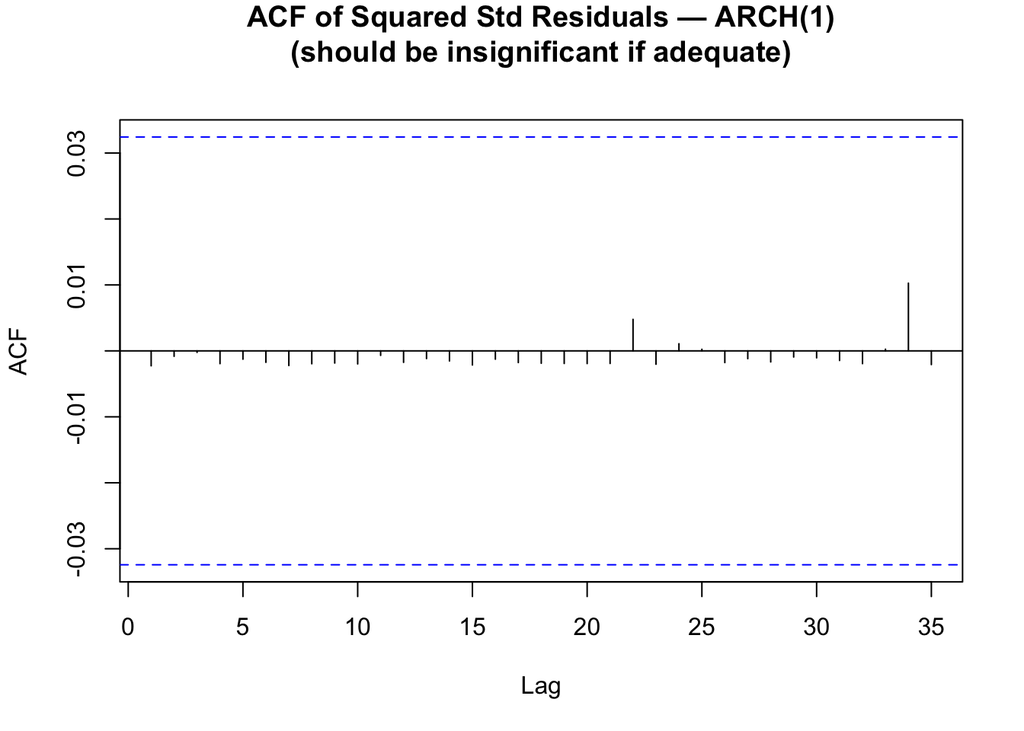

```r
Acf(as.numeric(z_arch)^2,
    main = "ACF of Squared Std Residuals — ARCH(1)\n(should be insignificant if adequate)")
```

**Interpretation:** The Ljung–Box test on standardized residuals strongly rejects the null hypothesis of no serial correlation (p < 2.2e-16), indicating that some linear dependence remains in the residuals and the mean specification may not fully capture all temporal dynamics. However, the ARCH LM test on standardized residuals yields a p-value of 1, suggesting that the GARCH component successfully removes remaining ARCH effects and adequately models conditional heteroskedasticity.

### GARCH(1,1) — Full Volatility Model

```r
spec_garch <- ugarchspec(
  variance.model     = list(model = "sGARCH", garchOrder = c(1, 1)),
  mean.model         = list(armaOrder = c(0, 2), include.mean = TRUE),
  distribution.model = "std"   # Student-t to handle heavy tails
)

fit_garch <- ugarchfit(spec_garch, data = btc_ret)
show(fit_garch)
```

```
##
## *---------------------------------*
## *          GARCH Model Fit        *
## *---------------------------------*
##
## Conditional Variance Dynamics
## -----------------------------------
## GARCH Model  : sGARCH(1,1)
## Mean Model   : ARFIMA(0,0,2)
## Distribution : std
##
## Optimal Parameters
## ------------------------------------
##         Estimate  Std. Error  t value Pr(>|t|)
## mu      0.125474    0.032480  3.86308 0.000112
## ma1    -0.048339    0.014936 -3.23646 0.001210
## ma2     0.012953    0.014541  0.89076 0.373059
## omega   0.141241    0.052568  2.68685 0.007213
## alpha1  0.092630    0.011443  8.09472 0.000000
## beta1   0.906370    0.012995 69.74840 0.000000
## shape   3.203491    0.152889 20.95302 0.000000
##
## Robust Standard Errors:
##         Estimate  Std. Error  t value Pr(>|t|)
## mu      0.125474    0.032485  3.86256 0.000112
## ma1    -0.048339    0.015083 -3.20479 0.001352
## ma2     0.012953    0.014034  0.92292 0.356049
## omega   0.141241    0.096921  1.45728 0.145039
## alpha1  0.092630    0.013627  6.79765 0.000000
## beta1   0.906370    0.020547 44.11176 0.000000
## shape   3.203491    0.160196 19.99728 0.000000
##
## LogLikelihood : -8992.241
##
## Information Criteria
## ------------------------------------
##
## Akaike       4.9270
## Bayes        4.9389
## Shibata      4.9270
```

[output cut: 46 more lines]

```
## Negative Sign Bias 0.16775 0.8668
## Positive Sign Bias 0.09837 0.9216
## Joint Effect       0.83426 0.8413
##
##
## Adjusted Pearson Goodness-of-Fit Test:
## ------------------------------------
##   group statistic p-value(g-1)
## 1    20     65.99    4.216e-07
## 2    30     80.56    9.594e-07
## 3    40     83.16    4.908e-05
## 4    50     96.23    6.506e-05
##
##
## Elapsed time : 0.2751951
```

```r
z_garch <- residuals(fit_garch, standardize = TRUE)

cat("Ljung-Box on standardized residuals:\n")
```

```
## Ljung-Box on standardized residuals:
```

```r
print(Box.test(as.numeric(z_garch), lag = 20, type = "Ljung-Box"))
```

```
##
##  Box-Ljung test
##
## data:  as.numeric(z_garch)
## X-squared = 44.328, df = 20, p-value = 0.00136
```

```r
cat("\nARCH test on standardized residuals:\n")
```

```
##
## ARCH test on standardized residuals:
```

```r
print(ArchTest(as.numeric(z_garch), lags = 12))
```

```
##
##  ARCH LM-test; Null hypothesis: no ARCH effects
##
## data:  as.numeric(z_garch)
## Chi-squared = 7.0022, df = 12, p-value = 0.8575
```

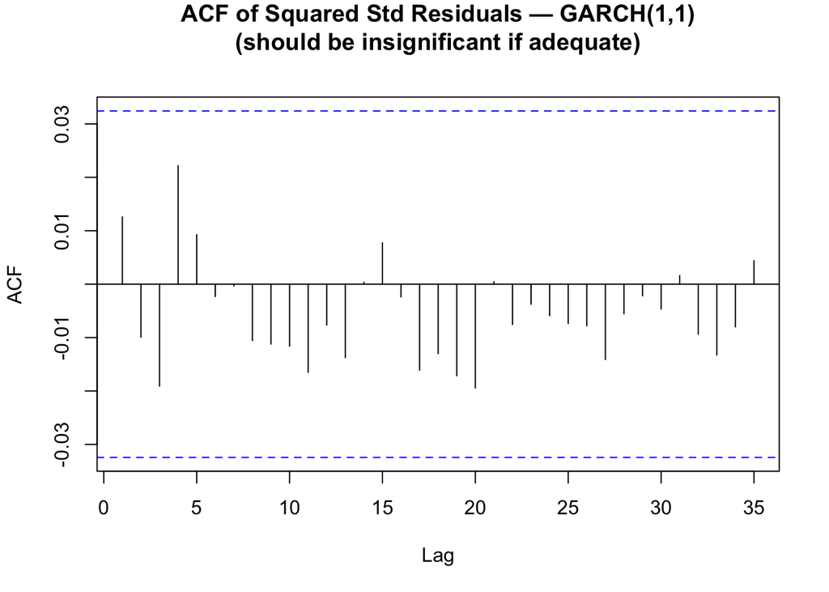

```r
Acf(as.numeric(z_garch)^2,
    main = "ACF of Squared Std Residuals — GARCH(1,1)\n(should be insignificant if adequate)")
```

**Interpretation:** Compared with the earlier ARCH specification, the GARCH model provides a better overall fit. In the ARCH model, the Ljung–Box test on standardized residuals produced an extremely small p-value (p < 2.2e-16), indicating strong remaining serial correlation and suggesting that the model did not adequately capture the underlying dynamics of the series. In the GARCH model, the Ljung–Box statistic is less small (p = 0.00136), showing that the remaining autocorrelation is substantially reduced. Additionally, the ARCH LM test yields a high p-value (p = 0.8575), meaning we fail to reject the null hypothesis of no remaining ARCH effects. This indicates that the GARCH specification successfully captures volatility clustering and improves the overall modeling of the conditional variance relative to the simpler ARCH model.

**Justification for GARCH(1,1) over ARCH(1):** - The ARCH(1) model only allows one lag of squared residuals to drive current variance - The GARCH(1,1) adds a lagged variance term, providing a longer “memory” of past volatility — well-suited for the persistent volatility clusters observed in BTC - Student-t distribution captures heavy tails better than Gaussian

## Model 3: VAR — Multivariate Mean Forecasting

VAR models the joint dynamics of all 7 stationary series, allowing each variable’s past values to help predict BTC returns. This tests H2 (macro Granger causality).

### Visualize Training Series

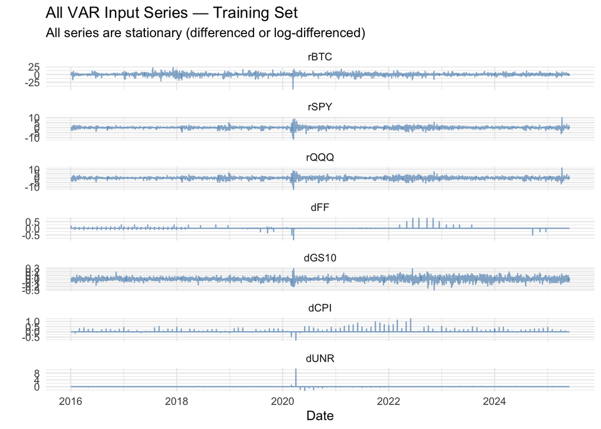

```r
tmp_df   <- data.frame(Date = index(train_xts), coredata(train_xts))
tmp_long <- reshape2::melt(tmp_df, id.vars = "Date",
                           variable.name = "Series", value.name = "Value")

ggplot(tmp_long, aes(x = Date, y = Value)) +
  geom_line(alpha = 0.6, color = "steelblue") +
  facet_wrap(~Series, scales = "free_y", ncol = 1) +
  theme_minimal() +
  labs(title = "All VAR Input Series — Training Set",
       subtitle = "All series are stationary (differenced or log-differenced)",
       x = "Date", y = "")
```

### ACF / PACF

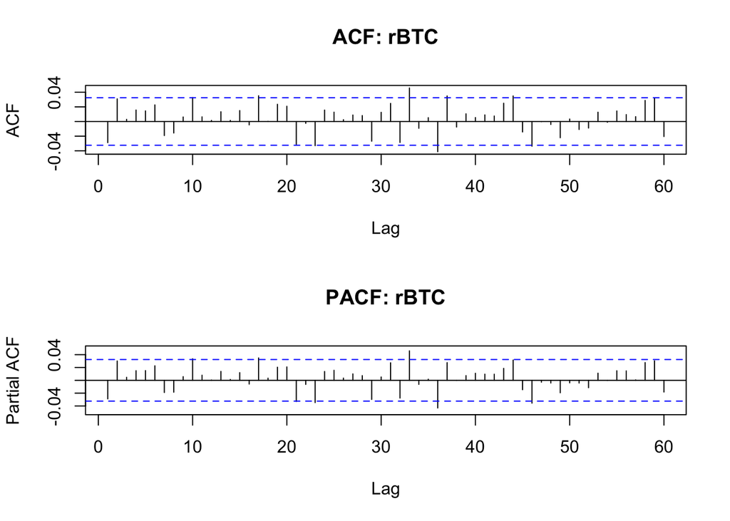

```r
par(mfrow = c(2, 1))
Acf(var_df$rBTC,  lag.max = 60, main = "ACF: rBTC")
Pacf(var_df$rBTC, lag.max = 60, main = "PACF: rBTC")
```

```r
par(mfrow = c(1, 1))
```

### Cross-Correlation (Predictors → BTC)

```r
par(mfrow = c(3, 2))
for (xnm in setdiff(colnames(var_df), "rBTC")) {
  ccf(as.numeric(var_df[, xnm]), as.numeric(var_df$rBTC),
      lag.max = 60,
      main    = paste("CCF:", xnm, "→ rBTC"),
      ylab    = "Cross-correlation")
}
```

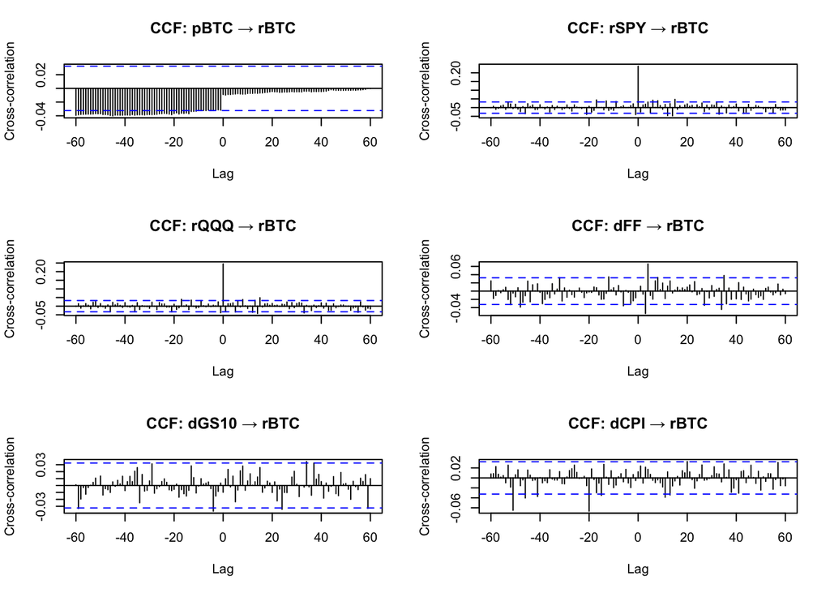

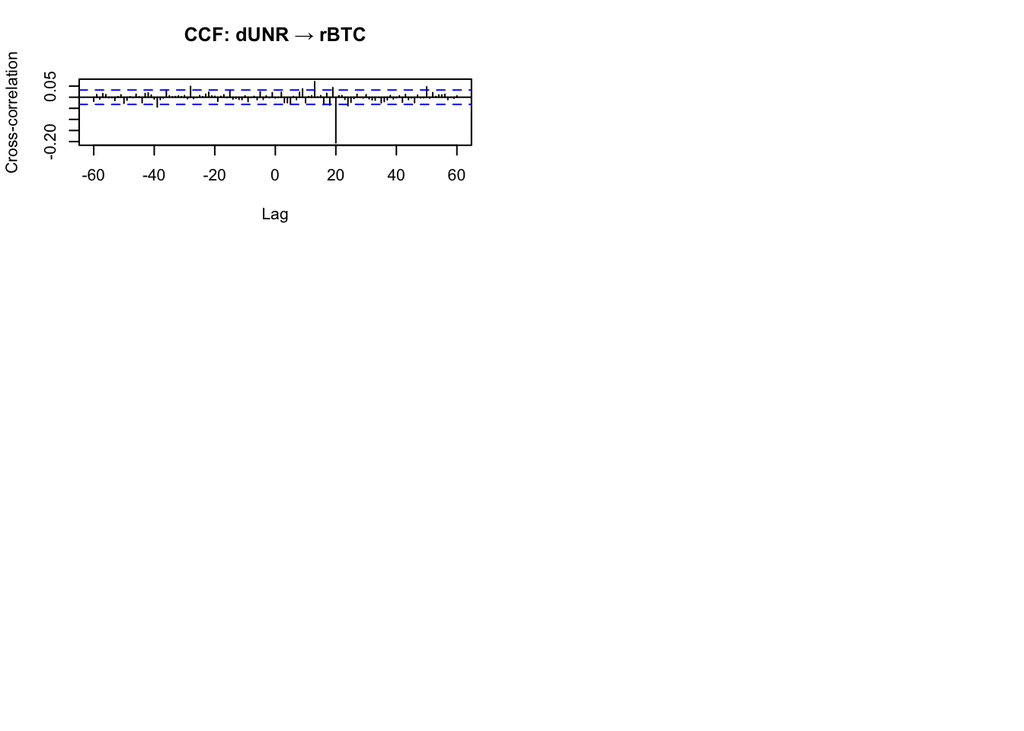

```r
par(mfrow = c(1, 1))
```

**Interpretation:** The cross-correlation function (CCF) plots examine whether lagged values of financial and macroeconomic variables contain predictive information for Bitcoin returns. Most correlations remain within the 95% confidence bounds, indicating that the lead-lag relationships between BTC returns and variables such as SPY, QQQ, interest rates, inflation, and unemployment are generally weak. A few isolated spikes appear at certain lags, particularly for unemployment and inflation, suggesting occasional delayed associations, but no consistent pattern emerges across the predictors. Overall, the CCF analysis suggests that Bitcoin returns exhibit limited short-term dependence on these external variables, although they may still contribute to the multivariate dynamics captured in the subsequent VAR modeling framework.

### Lag Order Selection

```r
ord <- VARorder(train_Y, maxp = 10, output = TRUE)
```

```
## selected order: aic =  9
## selected order: bic =  0
## selected order: hq =  0
## Summary table:
##        p      AIC      BIC       HQ     M(p) p-value
##  [1,]  0 -20.6972 -20.6972 -20.6972   0.0000  0.0000
##  [2,]  1 -20.7066 -20.6190 -20.6753 129.4443  0.0000
##  [3,]  2 -20.7034 -20.5283 -20.6408  86.4916  0.0008
##  [4,]  3 -20.7016 -20.4389 -20.6077  90.8459  0.0003
##  [5,]  4 -20.6979 -20.3477 -20.5728  84.2589  0.0013
##  [6,]  5 -20.7060 -20.2683 -20.5496 124.3521  0.0000
##  [7,]  6 -20.7129 -20.1876 -20.5252 119.6531  0.0000
##  [8,]  7 -20.7210 -20.1082 -20.5021 123.7185  0.0000
##  [9,]  8 -20.7526 -20.0522 -20.5024 202.7166  0.0000
## [10,]  9 -20.7634 -19.9755 -20.4820 132.1928  0.0000
## [11,] 10 -20.7476 -19.8721 -20.4349  42.5376  0.7310
```

```r
p <- ord$aicor[1]  # AIC-selected lag order
cat("AIC-selected lag order p =", p, "\n")
```

```
## AIC-selected lag order p = 9
```

### Granger Causality Tests

```r
cat("Pairwise Granger Causality Tests (alpha = 0.05)\n")
```

```
## Pairwise Granger Causality Tests (alpha = 0.05)
```

```r
cat("H0: predictor does NOT Granger-cause rBTC\n\n")
```

```
## H0: predictor does NOT Granger-cause rBTC
```

```r
alpha <- 0.05
for (cause_var in setdiff(colnames(train_xts), "rBTC")) {
  formula_obj <- as.formula(paste("rBTC ~", cause_var))
  test_result <- grangertest(formula_obj, order = p, data = train_xts)
  pval        <- test_result$`Pr(>F)`[2]
  verdict     <- if (pval < alpha) "GRANGER-CAUSES" else "does NOT cause"

  cat(sprintf("%-6s -> rBTC: F = %6.3f, p = %7.4f => %s\n",
              cause_var, test_result$F[2], pval, verdict))
}
```

```
## rSPY   -> rBTC: F =  1.042, p =  0.4032 => does NOT cause
## rQQQ   -> rBTC: F =  0.856, p =  0.5640 => does NOT cause
## dFF    -> rBTC: F =  1.444, p =  0.1632 => does NOT cause
## dGS10  -> rBTC: F =  0.794, p =  0.6222 => does NOT cause
## dCPI   -> rBTC: F =  0.489, p =  0.8830 => does NOT cause
## dUNR   -> rBTC: F =  0.666, p =  0.7400 => does NOT cause
```

**Interpretation:** These results report pairwise Granger causality tests evaluating whether other financial and macroeconomic variables help predict Bitcoin returns (rBTC). The null hypothesis for each test is that the predictor does not Granger-cause rBTC, meaning that its past values do not provide additional predictive information beyond the past values of Bitcoin returns themselves. Using a significance level of α = 0.05, all p-values are well above 0.05. This means we fail to reject the null hypothesis for every predictor, including equity market returns and macroeconomic variables. In other words, based on this test and the selected lag structure, none of these variables provide statistically significant predictive power for Bitcoin returns. This result suggests that BTC returns are largely driven by their own past dynamics rather than short-term spillovers from traditional financial markets or macroeconomic indicators, which is consistent with the weak lead–lag relationships observed in the earlier cross-correlation analysis. Nonetheless, we will fit VAR to confirm this.

### VAR Model Fit

```r
var_fit <- MTS::VAR(train_Y, p = p, include.mean = TRUE)

cat("Residual Covariance Matrix (Sigma):\n")
print(round(var_fit$Sigma, 6))
```

[output not shown]

### VAR Residual Diagnostics

```r
# Multivariate Ljung-Box (Portmanteau) test on VAR residuals
mq(var_fit$residuals, lag = 10)
```

```
## Ljung-Box Statistics:
##           m       Q(m)     df    p-value
##  [1,]   1.000     0.148  49.000        1
##  [2,]   2.000     1.301  98.000        1
##  [3,]   3.000     5.105 147.000        1
##  [4,]   4.000     8.391 196.000        1
##  [5,]   5.000    13.087 245.000        1
##  [6,]   6.000    20.727 294.000        1
##  [7,]   7.000    27.351 343.000        1
##  [8,]   8.000    36.236 392.000        1
##  [9,]   9.000    43.315 441.000        1
## [10,]  10.000    98.686 490.000        1
```

[figure not shown]

**Interpretation:** The Ljung–Box test results evaluate whether there is remaining serial correlation in the residuals of the fitted VAR model. The null hypothesis of the test is that the residuals are independently distributed (no autocorrelation) up to lag m. Across all tested lags from m=1 to m=10, the reported p-values are equal to 1, which are far above the 0.05 significance threshold. This means we fail to reject the null hypothesis at every lag, indicating that there is no evidence of residual autocorrelation remaining in the model errors. The accompanying plot confirms this result, as all p-values lie well above the significance boundary (blue dashed line). Overall, these diagnostics suggest that the VAR model with the selected lag structure adequately captures the temporal dependencies in the data, leaving residuals that behave approximately like white noise, which is a desirable property for a well-specified time series model. This is reflected below in the residuals plot below as well.

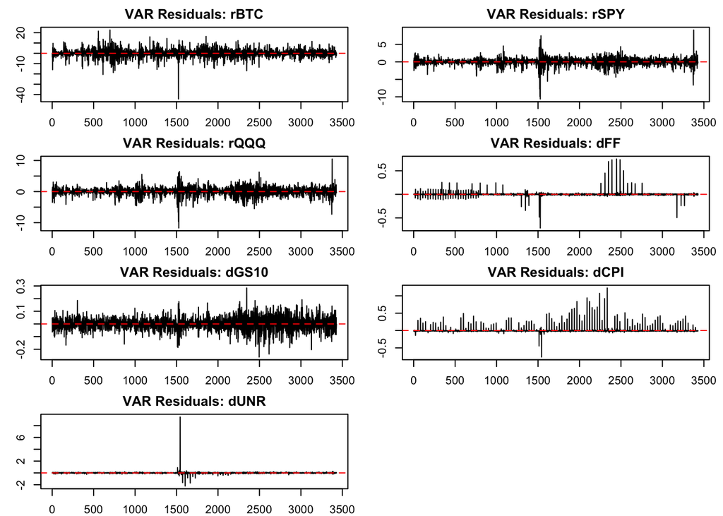

```r
residuals_var <- var_fit$residuals
colnames(residuals_var) <- colnames(train_Y)

par(mfrow = c(4, 2), mar = c(2, 3, 2, 1))
for (i in 1:7) {
  plot(residuals_var[, i], type = "l",
       main = paste("VAR Residuals:", colnames(residuals_var)[i]),
       ylab = "", xlab = "")
  abline(h = 0, lty = 2, col = "red")
}
par(mfrow = c(1, 1))
```

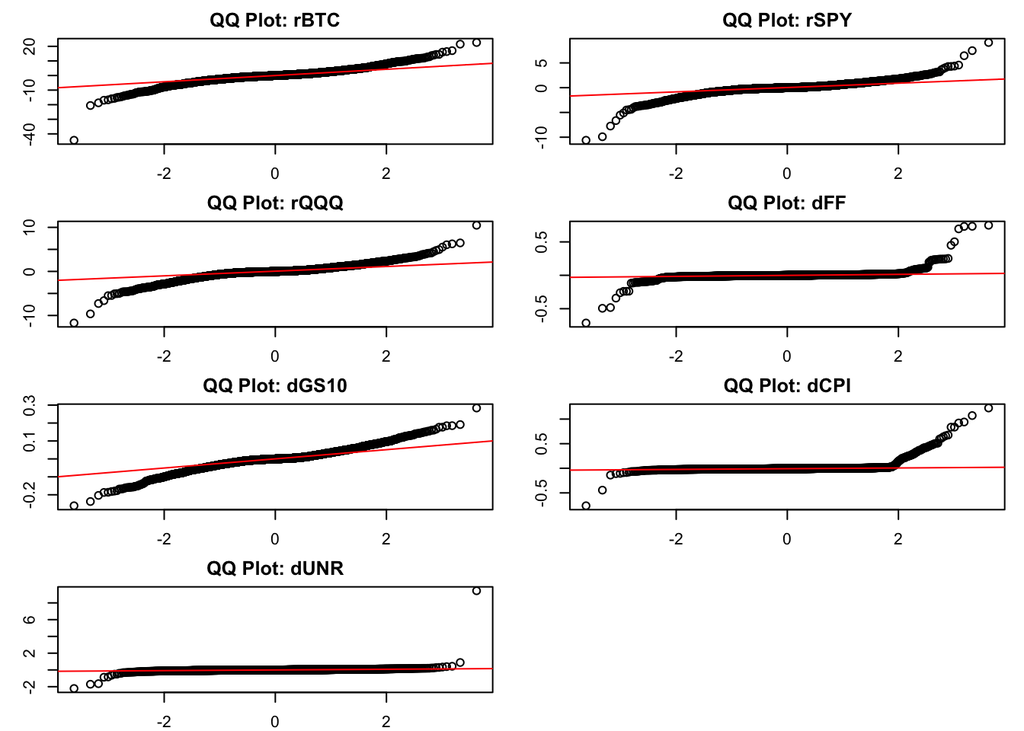

```r
par(mfrow = c(4, 2), mar = c(2, 3, 2, 1))
for (i in 1:7) {
  qqnorm(residuals_var[, i],
         main = paste("QQ Plot:", colnames(residuals_var)[i]))
  qqline(residuals_var[, i], col = "red")
}
par(mfrow = c(1, 1))
```

**Interpretation:** The QQ plots show the distribution of the VAR model residuals for each variable compared with a theoretical normal distribution. If the residuals were perfectly normal, the points would lie along the red reference line. While the residuals for most variables align closely with the line in the center of the distribution, several plots exhibit noticeable deviations in the tails, particularly for BTC and equity return residuals, where extreme observations fall away from the line. This indicates the presence of heavy tails and occasional outliers, meaning the residuals are not perfectly normally distributed. However, the relatively good alignment in the middle suggests the model captures the main dynamics of the series reasonably well, while the tail deviations reflect the well-known tendency of financial returns to produce extreme shocks more frequently than a normal distribution would predict.

### VAR Multi-Step Forecast (Test Set)

```r
h <- nrow(test_Y)

# h-step ahead forecast from end of training
fc       <- VARpred(var_fit, h = h)
pred_mat <- fc$pred
colnames(pred_mat) <- colnames(train_Y)

actual_rBTC <- test_Y[, "rBTC"]
pred_rBTC   <- pred_mat[, "rBTC"]

rmse_var <- sqrt(mean((actual_rBTC - pred_rBTC)^2))
mae_var  <- mean(abs(actual_rBTC - pred_rBTC))
```

```r
cat("VAR Multi-Step Forecast Accuracy (rBTC):\n")
```

```
## VAR Multi-Step Forecast Accuracy (rBTC):
```

```r
cat(sprintf("  RMSE: %.4f\n  MAE:  %.4f\n", rmse_var, mae_var))
```

```
##   RMSE: 1.8726
##   MAE:  1.4031
```

## Model 4: VAR + GARCH — Rolling 1-Step Forecast

### Static VAR + GARCH Diagnostics

```r
# Re-fit VAR on full training set
var_fit <- MTS::VAR(train_Y, p = p, include.mean = TRUE)
```

```
## Constant term:
## Estimates:  0.1792763 0.03785705 0.06400717 0.0007199267 -0.0002620622 0.01001791 -0.0004107074
## Std.Error:  0.06819258 0.01768077 0.02204833 0.0007520634 0.0008331477 0.001296428 0.003464136
## AR coefficient matrix
## AR( 1 )-matrix
##           [,1]     [,2]      [,3]    [,4]      [,5]     [,6]     [,7]
## [1,] -2.32e-02 -0.07498 -0.022438 -1.5267  9.66e-01 -0.43969  0.22863
## [2,]  3.62e-04 -0.09730 -0.002825 -0.2409 -5.21e-01  0.40122  0.15979
## [3,] -1.61e-03 -0.13700 -0.000623 -0.2659 -4.34e-01  0.43092  0.17329
## [4,]  4.13e-05 -0.00139  0.002095 -0.0182 -4.68e-02  0.00496 -0.00183
## [5,]  3.47e-04 -0.00334 -0.000218 -0.0206  9.96e-06  0.01788 -0.00122
## [6,]  4.37e-04 -0.00939  0.006805 -0.0793 -1.38e-02 -0.01894 -0.00527
## [7,]  2.23e-04 -0.01542  0.008165 -0.0638  6.56e-02  0.01834  0.00163
## standard error
##          [,1]    [,2]    [,3]   [,4]   [,5]   [,6]    [,7]
```

[output cut: 174 more lines]

```r
colnames(var_fit$residuals) <- colnames(train_Y)

resid_BTC <- na.omit(as.numeric(var_fit$residuals[, "rBTC"]))

cat("ARCH Test on VAR residuals (BTC equation):\n")
```

```
## ARCH Test on VAR residuals (BTC equation):
```

```r
ArchTest(resid_BTC, lags = 12)
```

```
##
##  ARCH LM-test; Null hypothesis: no ARCH effects
##
## data:  resid_BTC
## Chi-squared = 90.684, df = 12, p-value = 3.64e-14
```

```r
spec_var_garch <- ugarchspec(
  variance.model     = list(model = "sGARCH", garchOrder = c(1, 1)),
  mean.model         = list(armaOrder = c(0, 0), include.mean = FALSE),
  distribution.model = "std"
)

fit_var_garch <- ugarchfit(spec = spec_var_garch, data = resid_BTC)
show(fit_var_garch)
```

```
##
## *---------------------------------*
## *          GARCH Model Fit        *
## *---------------------------------*
##
## Conditional Variance Dynamics
## -----------------------------------
## GARCH Model  : sGARCH(1,1)
## Mean Model   : ARFIMA(0,0,0)
## Distribution : std
##
## Optimal Parameters
## ------------------------------------
##         Estimate  Std. Error  t value Pr(>|t|)
## omega   0.160169    0.067124   2.3862 0.017024
## alpha1  0.094391    0.012870   7.3344 0.000000
## beta1   0.904609    0.015118  59.8346 0.000000
## shape   3.257426    0.167170  19.4857 0.000000
##
## Robust Standard Errors:
##         Estimate  Std. Error  t value Pr(>|t|)
## omega   0.160169    0.135788   1.1796  0.23818
## alpha1  0.094391    0.017752   5.3173  0.00000
## beta1   0.904609    0.027528  32.8610  0.00000
## shape   3.257426    0.172421  18.8923  0.00000
##
## LogLikelihood : -8561.551
##
## Information Criteria
## ------------------------------------
##
## Akaike       4.9959
## Bayes        5.0031
## Shibata      4.9959
## Hannan-Quinn 4.9985
##
## Weighted Ljung-Box Test on Standardized Residuals
## ------------------------------------
##                         statistic  p-value
## Lag[1]                      10.30 0.001328
```

[output cut: 37 more lines]

```
## Negative Sign Bias  0.1759 0.8604
## Positive Sign Bias  0.2318 0.8167
## Joint Effect        0.6906 0.8754
##
##
## Adjusted Pearson Goodness-of-Fit Test:
## ------------------------------------
##   group statistic p-value(g-1)
## 1    20     49.31    0.0001652
## 2    30     61.17    0.0004401
## 3    40     70.60    0.0014461
## 4    50     77.58    0.0057510
##
##
## Elapsed time : 0.143259
```

```r
z_vg <- residuals(fit_var_garch, standardize = TRUE)
cat("\nLjung-Box on VAR+GARCH standardized residuals:\n")
```

```
##
## Ljung-Box on VAR+GARCH standardized residuals:
```

```r
print(Box.test(as.numeric(z_vg), lag = 20, type = "Ljung-Box"))
```

```
##
##  Box-Ljung test
##
## data:  as.numeric(z_vg)
## X-squared = 26.79, df = 20, p-value = 0.1413
```

```r
cat("\nARCH test on VAR+GARCH standardized residuals:\n")
```

```
##
## ARCH test on VAR+GARCH standardized residuals:
```

```r
print(ArchTest(as.numeric(z_vg), lags = 12))
```

```
##
##  ARCH LM-test; Null hypothesis: no ARCH effects
##
## data:  as.numeric(z_vg)
## Chi-squared = 7.1023, df = 12, p-value = 0.8508
```

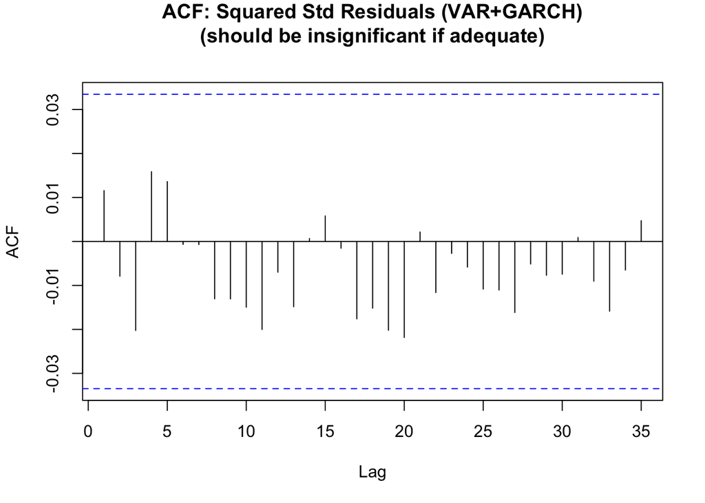

```r
Acf(as.numeric(z_vg)^2,
    main = "ACF: Squared Std Residuals (VAR+GARCH)\n(should be insignificant if adequate)")
```

**Interpretation:** The Ljung–Box test on the standardized residuals has a p-value of 0.141, so we fail to reject the null hypothesis of no autocorrelation in the residuals. This suggests that the VAR model adequately captures the mean dynamics of the series. In addition, the ARCH LM test yields a p-value of 0.85, meaning we also fail to reject the null hypothesis of no remaining ARCH effects. This indicates that the GARCH(1,1) specification has successfully captured the volatility clustering in the residuals. The squared residual ACF plot supports this conclusion, as it shows no significant spikes. Overall, these diagnostics suggest that the static VAR + GARCH specification is reasonably well specified, with residuals that behave approximately like white noise.